# Análise de clusters Variáveis do Censo Agro 2017

## Variáveis utilizadas

- Para a identificação do predomínio ou alta expressão da agricultura familiar nas microrregiões:
  - Proporção de área dos estabelecimentos da agricultura familiar, pelo total de área dos estabelecimentos nas microrregiões;
- Para a identificação da distribuição da mão de obra na agricultura familiar e na patronal:
  - Proporção de pessoas ocupadas na agricultura familiar, pelo total de ocupados nas microrregiões;
  - Pessoas ocupadas por hectare útil da agricultura familiar nas microrregiões;
  - Pessoas ocupadas por hectare útil da agricultura patronal (não familiar) nas microrregiões;
- Para a identificação de microrregiões com maior ou menor valor médio da produção por área utilizável:
  - Valor da produção por hectare útil da agricultura familiar nas microrregiões;
  - Valor da produção por hectare útil da agricultura patronal (não familiar) nas microrregiões;
- Para a inclusão de questões relacionadas a renda e importância dos rendimentos obtidos por políticas públicas nos estabelecimentos:
  - Rendimentos dos estabelecimentos da agricultura familiar nas microrregiões;
  - Rendimentos dos estabelecimentos da agricultura patronal (não familiar) nas microrregiões;
  - Proporção da renda dos estabelecimentos da agricultura familiar composta por programas e políticas.

Observação: Ao tratar de área utilizável dos estabelecimentos (hectare útil), o trabalho refere-se a totalidade das áreas dos estabelecimentos, excluídas as áreas de matas ou florestas naturais destinadas à preservação permanente ou reserva legal

## Número ideal de clusters

Após a normalização dos valores (com desvio padrão de 1 e média 0), uma vez que é necessário indicar previamente um número de clusters para iniciar o procedimento de clusterização das variáveis, foram verificados três métodos diferentes para determinar o número ideal de clusters, sendo eles: 1. Método do cotovelo (Elbow method) 2. Método de silhueta (Average Silhouette Method) 3. Método Gap (Gap Statistic Method)

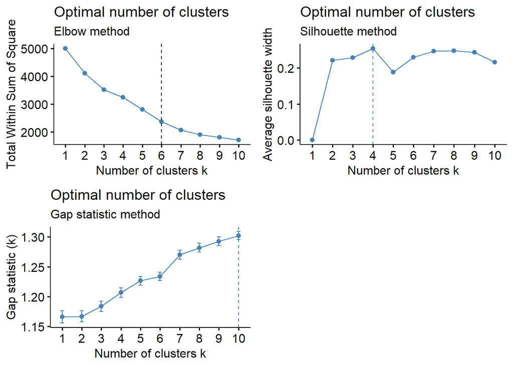

Uma vez que os valores indicados são divergentes, optou-se pelo número de seis clusters, valor indicado no primeiro método e média das três opções.

## Descrição dos clusters

**Sumário das médias das microrregiões para cada um dos clusters calculados**

| Médias das microrregiões | CL 1 | CL 2 | CL 3 | CL 4 | CL 5 | CL 6 |
| --- | --- | --- | --- | --- | --- | --- |
| Proporção de área AF | 15.9% | 42.2% | 8.3% | 40.9% | 50.7% | 39.1% |
| Proporção de ocupados na AF | 45.63% | 72.94% | 36.84% | 73.72% | 76.62% | 70.28% |
| Ocupados por ha útil da AF | 1 emprego a cada 5.12 ha | 1 emprego a cada 4.6 ha | 1 emprego a cada 12.5 ha | 1 emprego a cada 4.81 ha | 1 emprego a cada 4.85 ha | 1 emprego a cada 0.87 ha |
| Ocupados por ha útil da AP | 1 emprego a cada 21.81 ha | 1 emprego a cada 13.33 ha | 1 emprego a cada 83.04 ha | 1 emprego a cada 17.45 ha | 1 emprego a cada 14.11 ha | 1 emprego a cada 3.13 ha |
| VP/ha da AF | R$ 2960 /ha | R$ 763 /ha | R$ 1720 /ha | R$ 1171 /ha | R$ 5304 /ha | R$ 7444 /ha |
| VP/ha da AP | R$ 2947 /ha | R$ 591 /ha | R$ 2646 /ha | R$ 921 /ha | R$ 5172 /ha | R$ 5154 /ha |
| Prop. das rendas de programas/políticas na AF | 1.470% | 56.856% | 0.621% | 0.461% | 0.663% | 0.805% |
| Rendimentos da AF | R$ 161356 | R$ 215817 | R$ 305306 | R$ 186728 | R$ 748681 | R$ 82751 |
| Rendimentos da AP | R$ 803849 | R$ 172483 | R$ 4579778 | R$ 222948 | R$ 745295 | R$ 109002 |
| Nº total de microrregiões | 202 | 22 | 23 | 236 | 51 | 23 |

**Representação espacial dos clusters**

[interactive chart not shown]

### Cluster 1

- Predominancia patronal, rentabilidade por hectare similar a familiar.

### Cluster 2

Sem nítida predominância em área de uma das duas tipologias (em média 42% da área das microrregiões sendo familiar), a maioria das pessoas ocupadas (mais de 70%) é da AF. Esse cluster possui como média o menor valor da produção por hectare tanto para a AF quanto para a AP. Nesse cluster, tanto os valores de VP/ha quanto a média do total de receitas obtidas nas microrregiões são superiores na agricultura familiar, sendo cerca de 1,3x maior em ambos os casos. Esse é o único cluster no qual, em média, os estabelecimentos contam com 50% da sua renda advinda de programas e políticas.

- Familiar com rendas de programas e políticas.

### Cluster 3

No terceiro cluster gerado, a agricultura familiar é praticamente inexpressiva em área, mas ainda assim, dentro das microrregiões, a média das receitas é relativamente boa quando comparada com a dos demais clusters (não sendo superior apenas ao cluster 5). Esse cluster é dominado pelos estabelecimentos patronais (mais de 90% da área) e, apesar da média dos rendimentos da AP ser muito superior a da AF (aproximadamente 15x maior), o valor da produção por hectare da AF é apenas 1,5x menor do que na AP.

- Quase exclusivamente patronal, mais rentável por hectare do que a familiar e geradora de grande receita.

### Cluster 4

Tanto em área quanto em ocupadas na agricultura familiar, esse cluster apresenta valores muito próximos aos do cluster 2, as diferenças aqui são que: 1) não há uma importância da renda de programas e políticas na composição total da renda dos estabelecimentos; 2) apesar de seguir o mesmo padrão do segundo cluster, com o VP/ha da AF cerca de 1,3x maior que o da AP, a média para ambos os tipos de estabelecimento nesse cluster é superior, indicando que o cluster 4 uma maior rentabilidade por hectare. Fator importante a ser observado é que, apesar de gerar em média maior valor da produção por hectare na AF do que na AP, as receitas da AP são em média 1,2x superiores às da AF.

– Observação: É curioso a desimportância dos programas e políticas na composição das rendas dos estabelecimentos agropecuários, apesar da proximidade espacial com o cluster 2.

### Cluster 5

Sendo o único que, na média das microrregiões, predominam os estabelecimentos da AF em área (pouco mais de 50% da área sendo ocupada por estabelecimentos desse tipo), em termos de pessoal ocupado o Cluster 5 não difere muito dos clusters 2 e 4. O que diferencia esse cluster dos demais, especialmente dos aqui mencionados, que possuem alta expressão da AF, é o valor da produção por área muito maior do que em todos os demais clusters, com exceção do 6. Aqui, tanto a média do valor da produção por hectare, quanto a média do total das receitas é muito similar na AF e na AP, demonstrando um maior equilíbrio entre essas duas tipologias quando comparado com os demais clusters.

- Equilíbrio familiar e patronal, com alta receita e valor da produção por hectare útil.

### Cluster 6

Com média de 40% das áreas ocupadas por agricultura familiar, não sendo portanto tão dominante a agricultura patronal, esse cluster possui a média mais alta do VP/ha da AF (e o segundo mais alto da AP), mas apresenta a menor média de receitas dentre todos os clusters. Há muito mais ocupados por hectare do que todos os outros clusters (cerca de 5x mais tanto para a AF quanto para a AP), a agricultura familiar gera mais valor por hectare do que a patronal (1,4x mais), mas a média das receitas é extremamente baixa quando comparado com a média das receitas dos outros clusters, tanto na AF quanto na AP.

- Sem uma clara predominância de tipologia, com altíssimo valor da produção por hectare para a AF e alto para a AP, mas baixíssima receita.

### Tabela descritiva

Sumário com médias, medianas, mínimos e máximos das microrregiões para cada um dos clusters calculados

| Clusters | 1 (N = 202) | 2 (N = 22) | 3 (N = 23) | 4 (N = 236) | 5 (N = 51) | 6 (N = 23) |
| --- | --- | --- | --- | --- | --- | --- |
| **Proporção de área AF** |  |  |  |  |  |  |
| min | 0% | 12% | 1% | 11% | 21% | 8% |
| Mediana | 15% | 38% | 6% | 40% | 53% | 37% |
| max | 52% | 74% | 17% | 71% | 74% | 91% |
| Média | 16% | 42% | 8% | 41% | 51% | 39% |
| **Proporção de ocupados na AF** |  |  |  |  |  |  |
| min | 0% | 49% | 15% | 51% | 53% | 42% |
| Mediana | 49% | 73% | 38% | 75% | 76% | 75% |
| max | 71% | 85% | 61% | 96% | 91% | 95% |
| Média | 46% | 73% | 37% | 74% | 77% | 70% |
| **Ocupados por ha útil da AF** |  |  |  |  |  |  |
| min | 1 emprego a cada 1.1 ha | 1 emprego a cada 1.54 ha | 1 emprego a cada 5.53 ha | 1 emprego a cada 1.16 ha | 1 emprego a cada 1.84 ha | 1 emprego a cada 0.36 ha |
| Mediana | 1 emprego a cada 7.19 ha | 1 emprego a cada 6.66 ha | 1 emprego a cada 15.09 ha | 1 emprego a cada 5.75 ha | 1 emprego a cada 5.42 ha | 1 emprego a cada 1.11 ha |
| max | 1 emprego a cada Inf ha | 1 emprego a cada 12.23 ha | 1 emprego a cada 28.21 ha | 1 emprego a cada Inf ha | 1 emprego a cada 15.62 ha | 1 emprego a cada 1.83 ha |
| Média | 1 emprego a cada Inf ha | 1 emprego a cada 6.45 ha | 1 emprego a cada 15.09 ha | 1 emprego a cada Inf ha | 1 emprego a cada 5.61 ha | 1 emprego a cada 1.07 ha |
| **Ocupados por ha útil da AP** |  |  |  |  |  |  |
| min | 1 emprego a cada 3.96 ha | 1 emprego a cada 1.95 ha | 1 emprego a cada 35.52 ha | 1 emprego a cada 3.59 ha | 1 emprego a cada 5.17 ha | 1 emprego a cada 0.91 ha |
| Mediana | 1 emprego a cada 27.72 ha | 1 emprego a cada 24.18 ha | 1 emprego a cada 93.36 ha | 1 emprego a cada 23.66 ha | 1 emprego a cada 16.35 ha | 1 emprego a cada 4.74 ha |
| max | 1 emprego a cada Inf ha | 1 emprego a cada 78.19 ha | 1 emprego a cada 219.77 ha | 1 emprego a cada Inf ha | 1 emprego a cada 65.48 ha | 1 emprego a cada 9.63 ha |
| Média | 1 emprego a cada Inf ha | 1 emprego a cada 27.42 ha | 1 emprego a cada 109.36 ha | 1 emprego a cada Inf ha | 1 emprego a cada 20.96 ha | 1 emprego a cada 4.68 ha |
| **VP/ha da AF** |  |  |  |  |  |  |
| min | R$ 0 /ha | R$ 209 /ha | R$ 482 /ha | R$ 0 /ha | R$ 932 /ha | R$ 1652 /ha |
| Mediana | R$ 2576 /ha | R$ 496 /ha | R$ 1752 /ha | R$ 811 /ha | R$ 5010 /ha | R$ 4353 /ha |
| max | R$ 11803 /ha | R$ 2432 /ha | R$ 3820 /ha | R$ 5129 /ha | R$ 14083 /ha | R$ 19398 /ha |
| Média | R$ 2960 /ha | R$ 763 /ha | R$ 1720 /ha | R$ 1171 /ha | R$ 5304 /ha | R$ 7444 /ha |
| **VP/ha da AP** |  |  |  |  |  |  |
| min | R$ 0 /ha | R$ 76 /ha | R$ 744 /ha | R$ 0 /ha | R$ 758 /ha | R$ 265 /ha |
| Mediana | R$ 2475 /ha | R$ 344 /ha | R$ 2534 /ha | R$ 617 /ha | R$ 4743 /ha | R$ 3626 /ha |
| max | R$ 15963 /ha | R$ 2568 /ha | R$ 5010 /ha | R$ 4060 /ha | R$ 19305 /ha | R$ 24435 /ha |
| Média | R$ 2947 /ha | R$ 591 /ha | R$ 2646 /ha | R$ 921 /ha | R$ 5172 /ha | R$ 5154 /ha |
| **Prop. das rendas de programas/políticas na AF** |  |  |  |  |  |  |
| min | 0% | 33% | 0% | 0% | 0% | 0% |
| Mediana | 0% | 58% | 0% | 0% | 0% | 0% |
| max | 26% | 75% | 14% | 28% | 17% | 19% |
| Média | 1% | 57% | 1% | 0% | 1% | 1% |
| **Rendimentos da AF** |  |  |  |  |  |  |
| min | R$ 0 | R$ 27286 | R$ 53856 | R$ 16644 | R$ 159863 | R$ 1904 |
| Mediana | R$ 132089 | R$ 219278 | R$ 291277 | R$ 143916 | R$ 676155 | R$ 54563 |
| max | R$ 639782 | R$ 551930 | R$ 652991 | R$ 643237 | R$ 2463143 | R$ 277915 |
| Média | R$ 161356 | R$ 215817 | R$ 305306 | R$ 186728 | R$ 748681 | R$ 82751 |
| **Rendimentos da AP** |  |  |  |  |  |  |
| min | R$ 0 | R$ 5077 | R$ 2590165 | R$ 6694 | R$ 58369 | R$ 1760 |
| Mediana | R$ 684544 | R$ 114382 | R$ 3591361 | R$ 130318 | R$ 588276 | R$ 44496 |
| max | R$ 2510335 | R$ 527409 | R$ 10918837 | R$ 1776618 | R$ 2341559 | R$ 651433 |
| Média | R$ 803849 | R$ 172483 | R$ 4579778 | R$ 222948 | R$ 745295 | R$ 109002 |

Elaborado por Bruna Fernandes, 03/2021.